# Creating survival plot

After inserting the `survfit{survival}` object into `surv.plot{survSAKK}`, we can create simple survival curves, allowing to visualize survival patterns and incorporate various statistics in our plot.

To show some benefit of this function, *NCCTG Lung Cancer Data*, available in the survival package is used.

# Setup and Loading Data

```r
# Load required libraries
library(survSAKK)
library(survival)

# Load lung data
lung <- survival::lung

# Compute survival time in months and years
lung$time.m <- lung$time/365.25*12
lung$time.y <- lung$time/365.25

# Create survival objects
fit.lung.d <- survfit(Surv(time, status) ~ 1, data = lung)
fit.lung.m <- survfit(Surv(time.m, status) ~ 1, data = lung)
fit.lung.arm.m <- survfit(Surv(time.m, status) ~ sex, data = lung)
fit.lung.arm.y <- survfit(Surv(time.y, status) ~ sex, data = lung)
```

# Drawing basic survival plot

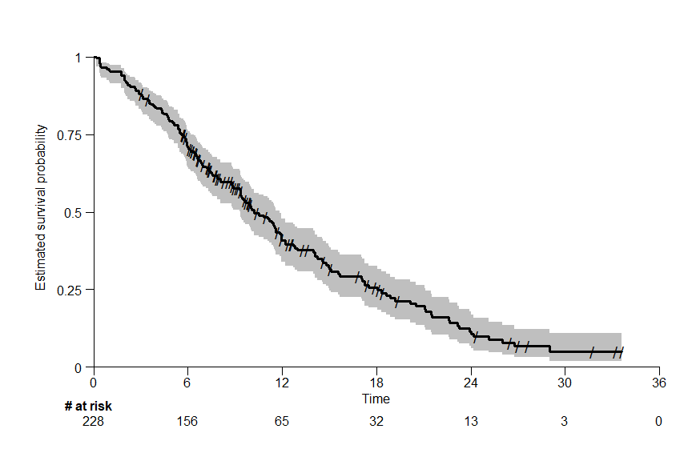

```r
# Single arm
surv.plot(fit.lung.m)
```

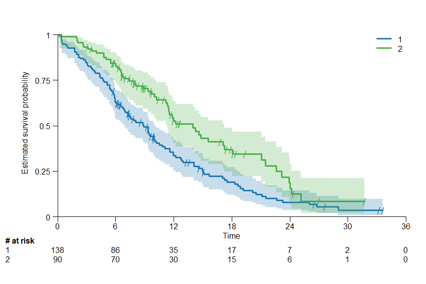

```r
# Two arm
surv.plot(fit.lung.arm.m)
```

# Customisation of the survival plot

## Colour, title and axis label

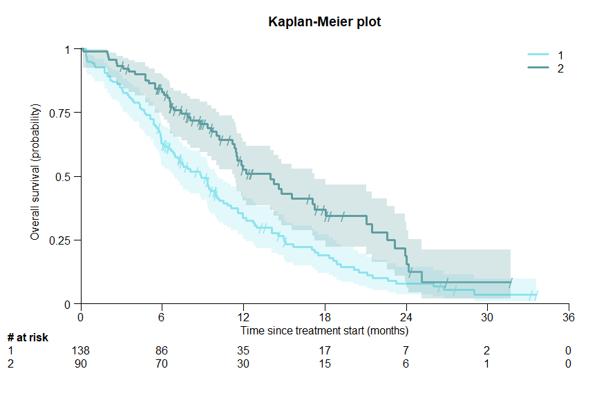

```r
surv.plot(fit.lung.arm.m,
          # Colour
          col = c("cadetblue2", "cadetblue"),
          # Title
          main = "Kaplan-Meier plot",
          # Axis label
          xlab = "Time since treatment start (months)",
          ylab = "Overall survival (probability)"
)
```

## Legend position, name and title

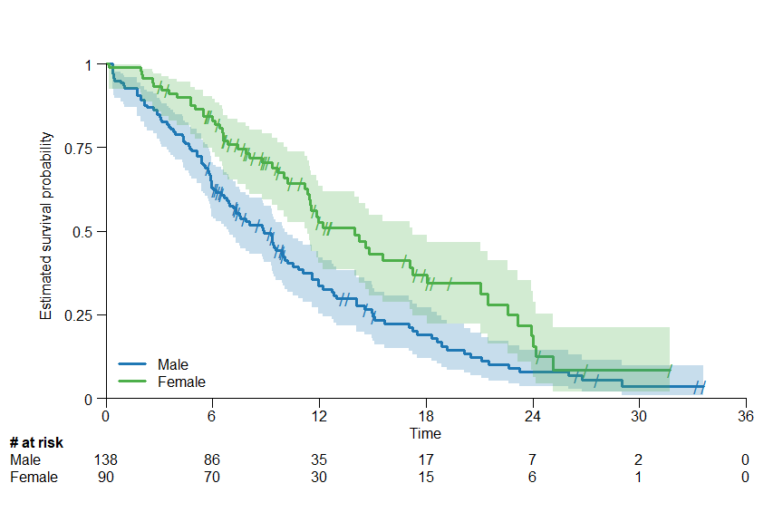

```r
# Choose legend position and names of the arms
surv.plot(fit.lung.arm.m,
          legend.position = "bottomleft",
          legend.name = c("Male", "Female")
)
```

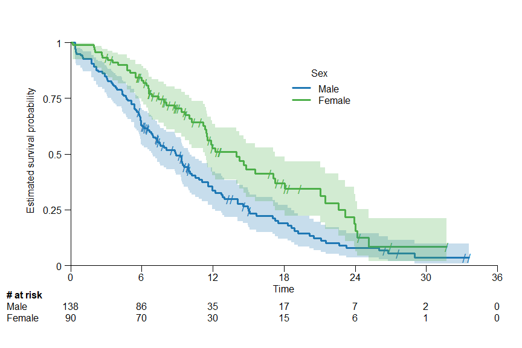

```r
# Choose legend position manually and add a legend title
surv.plot(fit.lung.arm.m,
          legend.position = c(18, 0.9),
          legend.name = c("Male", "Female"),
          legend.title = "Sex"
)
```

## Axis limits, xticks and yticks

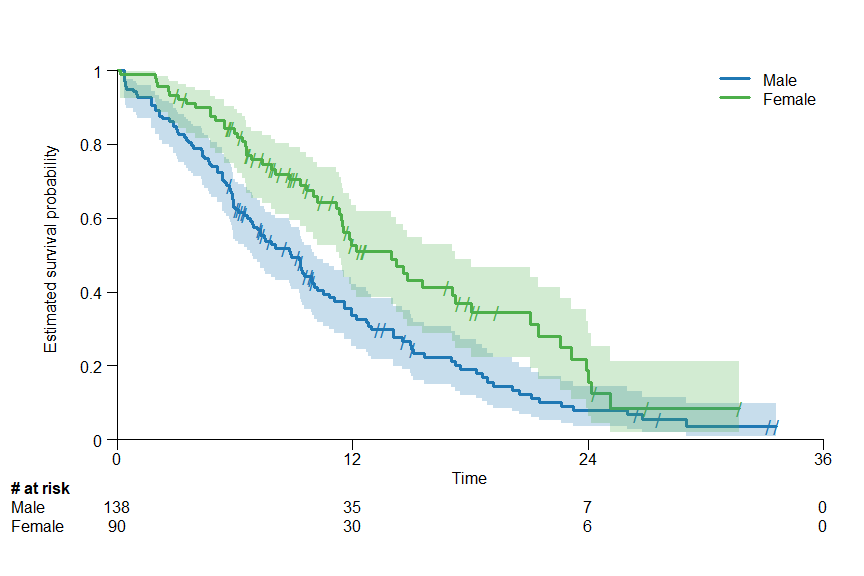

```r
surv.plot(fit.lung.arm.m,
          legend.name = c("Male", "Female"),
          xticks = seq(0, 36, by = 12),
          yticks = seq(0, 1, by = 0.2)
)
```

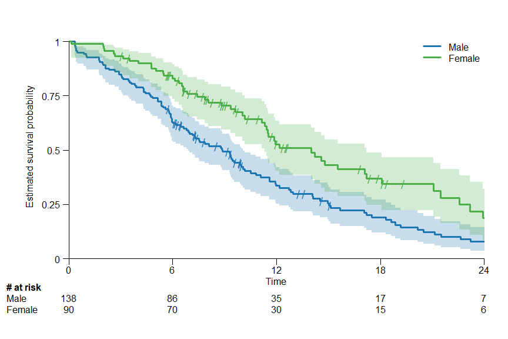

```r
# Cut curve at 24 months
surv.plot(fit.lung.arm.m,
          legend.name = c("Male", "Female"),
          xticks = seq(0, 24, by = 6)
)
```

## Font size

### Global adjustment

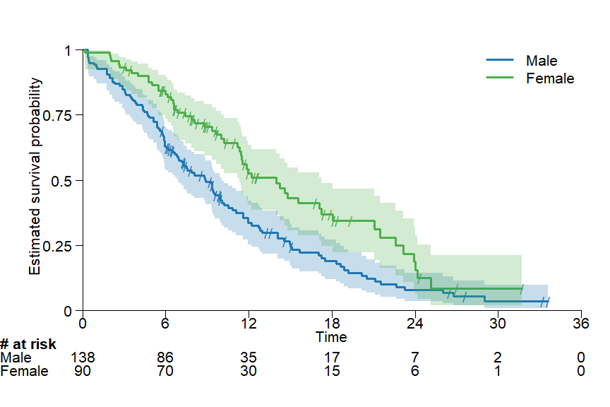

```r
surv.plot(fit.lung.arm.m,
          legend.name = c("Male", "Female"),
          # Global adjustment
          cex = 1.3,
          risktable.name.position = -6,
          risktable.title.position = -6
)
```

### Specific adjustment

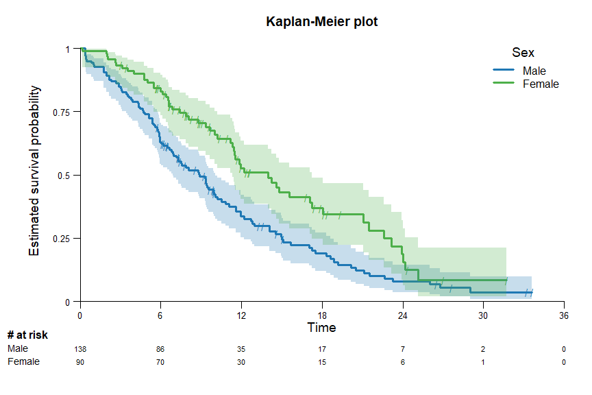

```r
surv.plot(fit.lung.arm.m,
          main = "Kaplan-Meier plot",
          legend.name = c("Male", "Female"),
          legend.title = "Sex",
          # Size of x-axis label
          xlab.cex = 1.2,
          # Size of y-axis label
          ylab.cex = 1.2,
          # Size of axis elements
          axis.cex = 0.8,
          # Size of the censoirng marks
          censoring.cex = 1,
          # Size of the legend title
          legend.title.cex = 1.2,
          # Size of the risktable
          risktable.cex = 0.7,
          # Size of the risktable name
          risktable.name.cex = 0.9
)
```

## Label position x and y axis

### Shift x and y axis label

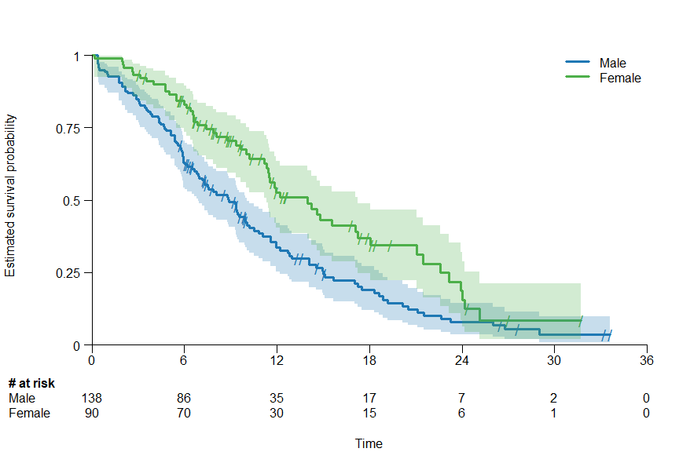

```r
surv.plot(fit.lung.arm.m,
          legend.name = c("Male", "Female"),
          xlab.pos = 6,
          ylab.pos = 5
)
```

## Margin area customisation

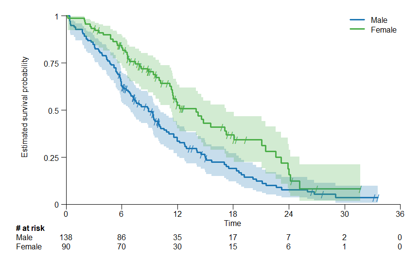

```r
# Change the margins and shift the y axis label
surv.plot(fit.lung.arm.m,
          legend.name = c("Male", "Female"),
          # New margin area
          margin.bottom = 6,
          margin.left = 7,
          margin.top = 1,
          margin.right = 2,
          # Define margin of the y-axis label
          ylab.pos = 4
)
```

## Time unit and y-axis unit

The parameter `time.unit` can be set as follows: `"day"`, `"week"`, `"month"`,`"year"`.

**Note the following:**

- The time unit in `time.unit` needs to correspond to the time unit which was used to calculate the survival object `fit`.
- If `time.unit = "month"` x ticks are automatically chosen by intervals of 6 months. Whereas for `time.unit = "year"` the x ticks are chosen by intervals of 1.

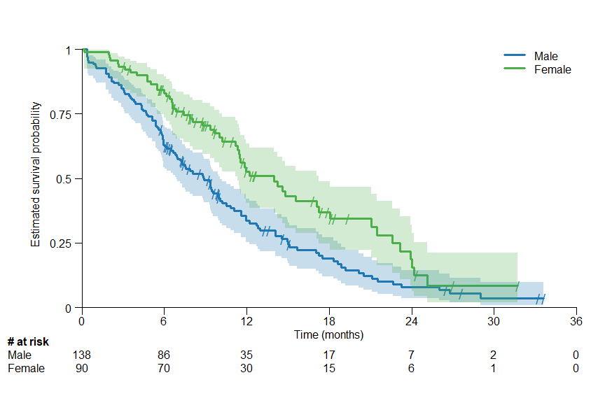

```r
# Time unit of month
surv.plot(fit.lung.arm.m,
          time.unit = "month",
          y.unit = "probability",
          legend.name = c("Male", "Female")
)
```

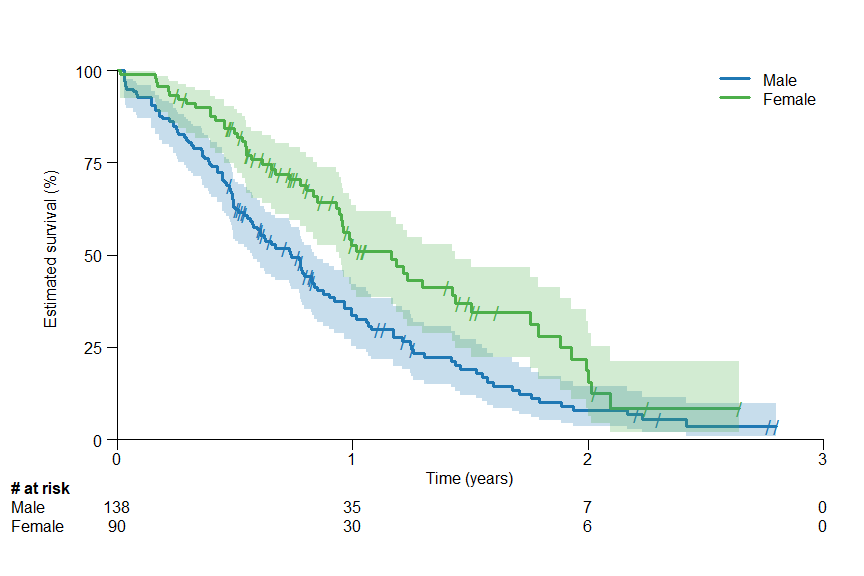

```r
# Time unit of year
surv.plot(fit.lung.arm.y,
          time.unit = "year",
          y.unit = "percent",
          legend.name = c("Male", "Female")
)
```

# Drawing risk table

Per default the risk table is provided below the Kaplan-Meier plot. It provides information about the number of patients at risk at different time points.

## Undisplay risk table

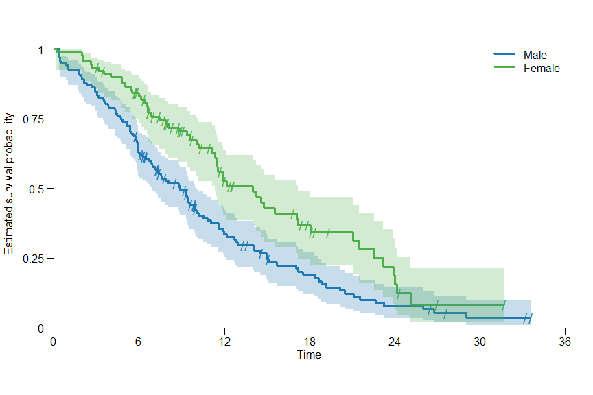

```r
surv.plot(fit.lung.arm.m,
          legend.name = c("Male", "Female"),
          risktable = FALSE
)
```

## Risktable position

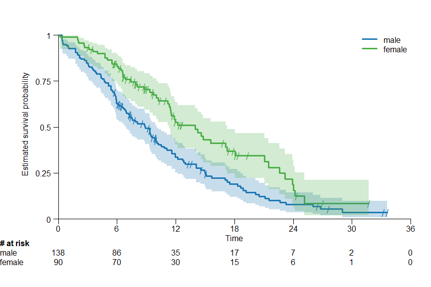

```r
# Move risk table names and titles to the left
surv.plot(fit.lung.arm.m,
          legend.name = c("male", "female"),
          risktable.name.position = -6,
          risktable.title.position = -6
)
```

## Risktable title, colour and label name

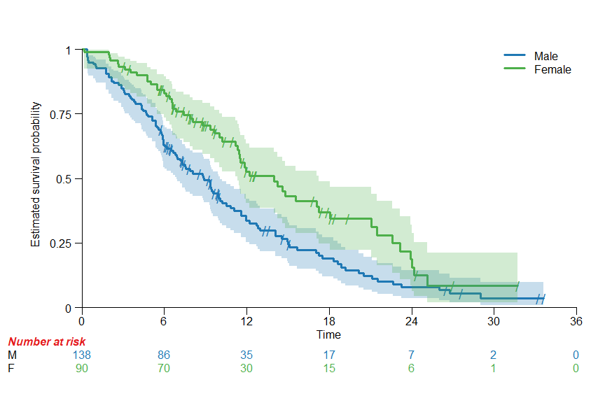

```r
surv.plot(fit.lung.arm.m,
          legend.name = c("Male", "Female"),
          risktable.name = c("M", "F"),
          risktable.col = TRUE,
          risktable.title = "Number at risk",
          risktable.title.font = 4,
          risktable.title.col = "#E41A1C"
)
```

## Risktable with censoring indication

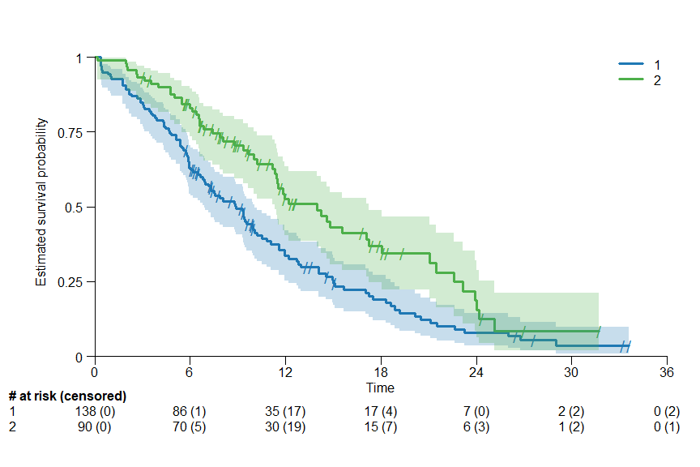

```r
surv.plot(fit.lung.arm.m,
          risktable.censoring = TRUE)
```

# Drawing segment

This section explains how to highlight a **specific quantile** or **time point** as a segment in the survival curve and how to adjust segment annotation.

## For a specific quantile

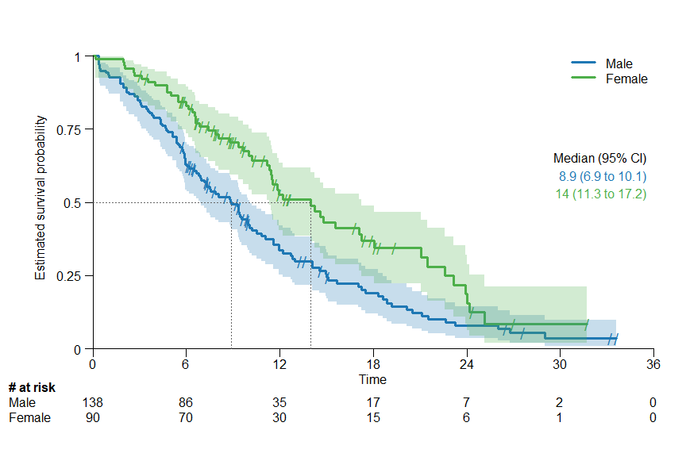

```r
# Drawing a segment line for the median, which corresponds to 0.5 quantile
surv.plot(fit.lung.arm.m,
          legend.name = c("Male", "Female"),
          segment.quantile = 0.5
)
```

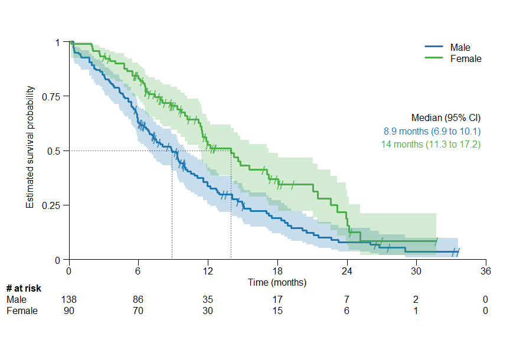

```r
surv.plot(fit.lung.arm.m,
          legend.name = c("Male", "Female"),
          segment.quantile = 0.5,
          # Specifying time unit
          time.unit = "month"
)
```

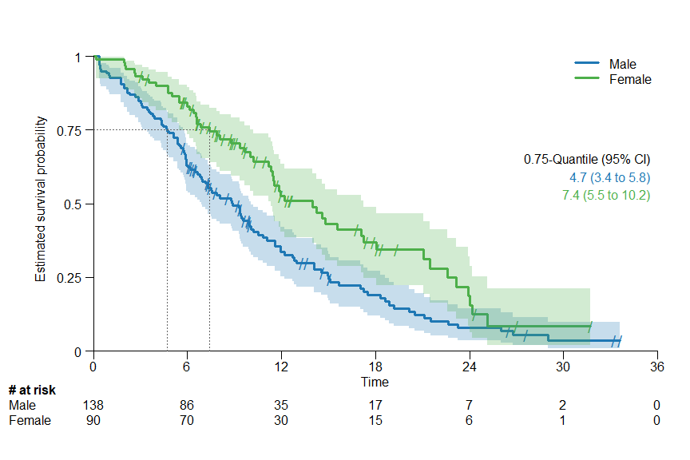

```r
# Drawing segment for the 0.75 quantile
surv.plot(fit.lung.arm.m,
          legend.name = c("Male", "Female"),
          segment.quantile = 0.75
)
```

## For a specific time point

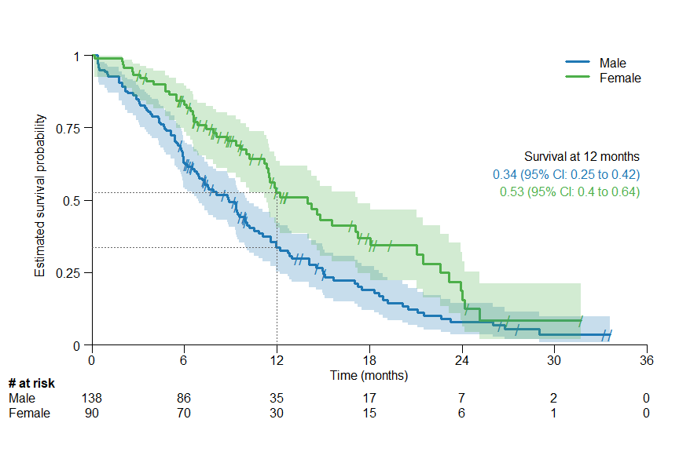

```r
#  Drawing a segment line at 12 months
surv.plot(fit.lung.arm.m,
          legend.name = c("Male", "Female"),
          time.unit = "month",
          segment.timepoint = 12
)
```

# Customisation of the segment

## Change position of segment annotation

The parameter `segment.annotation` can take the following values: `c(x,y)`, `"bottom"`, `"bottomleft"`, `"left"`, `"right"`, `"top"`, `"none"`

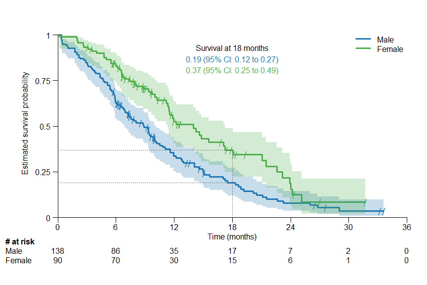

```r
surv.plot(fit.lung.arm.m,
          legend.name = c("Male", "Female"),
          segment.timepoint = 18,
          segment.annotation = "top",
          time.unit = "month"
)
```

## Segment title, font, size, and colour

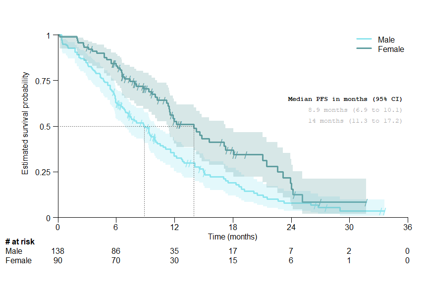

```r
surv.plot(fit.lung.arm.m,
          col = c("cadetblue2", "cadetblue"),
          legend.name = c("Male", "Female"),
          time.unit = "month",
          segment.quantile = 0.5,
          segment.font = 10,
          segment.main.font = 11,
          segment.main = "Median PFS in months (95% CI)",
          segment.cex = 0.8,
          segment.annotation.col = "darkgray"
)
```

## Segment lines for different time points / quantile

Note that `segment.annotation` can only be chosen as `"right"`, `"left"`, `"bottom"` or `"top"`.

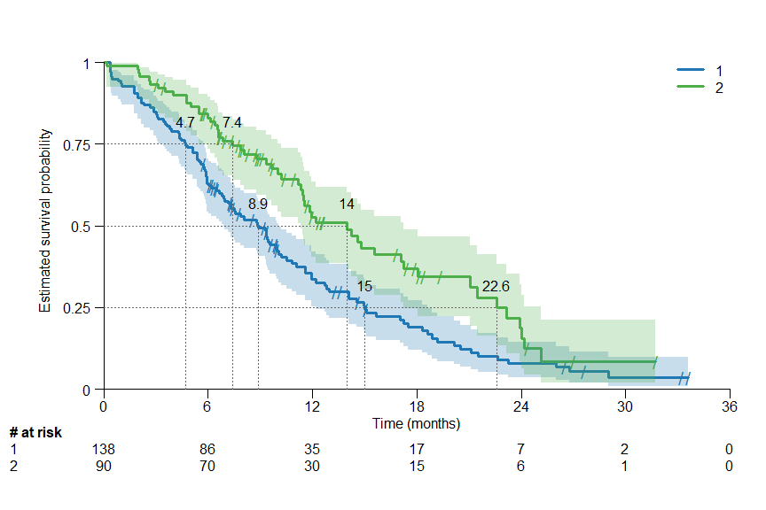

```r
# Several quantiles: Drawing a segment line at the 0.25, 0.5 and 0.75 quantile
surv.plot(fit.lung.arm.m,
          time.unit = "month",
          segment.quantile = c(0.25, 0.5, 0.75),
          segment.annotation = "top",
          segment.annotation.col = "black",
          segment.annotation.offset = 1
)
```

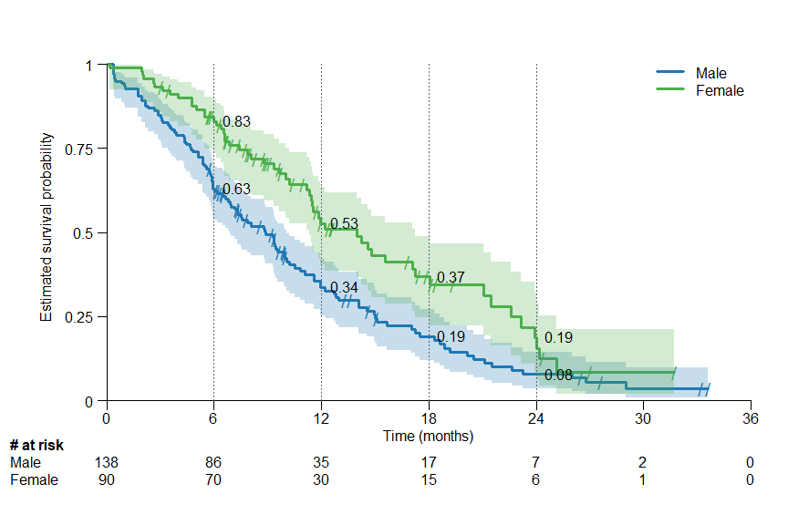

```r
# Several time points: Drawing a segment line at 6, 12, 18 and 24 months
surv.plot(fit.lung.arm.m,
          legend.name = c("Male", "Female"),
          time.unit = "month",
          segment.timepoint = c(6, 12, 18, 24),
          segment.type = 1,
          segment.annotation.col = "black"
)
```

## Segment line type, line width and text spacing

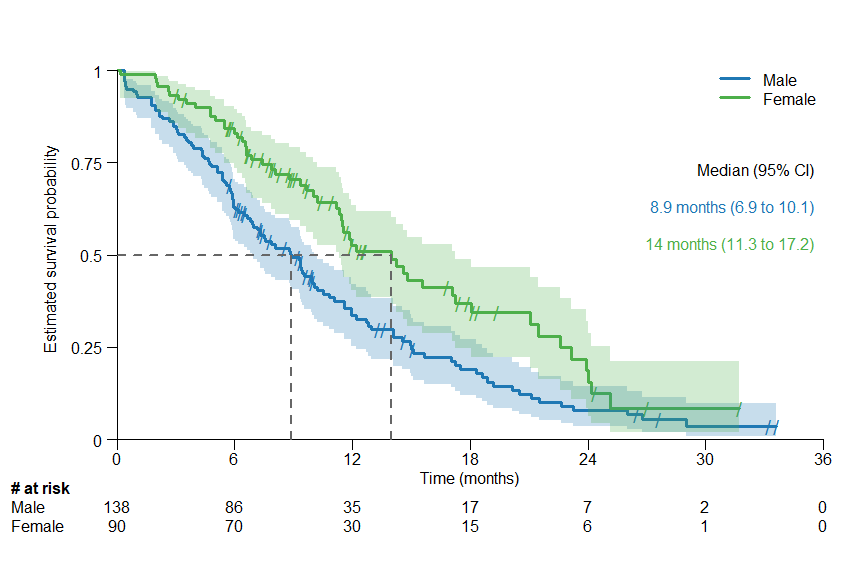

```r
surv.plot(fit.lung.arm.m,
          legend.name = c("Male", "Female"),
          time.unit = "month",
          segment.quantile = 0.5,
          segment.lwd = 2,
          segment.lty = "dashed",
          segment.annotation.space = 0.1
)
```

## Segment annotation short version

The confidence interval can be omitted in the segment annotation by setting `segment.confint = FALSE`.

Examples for one arm:

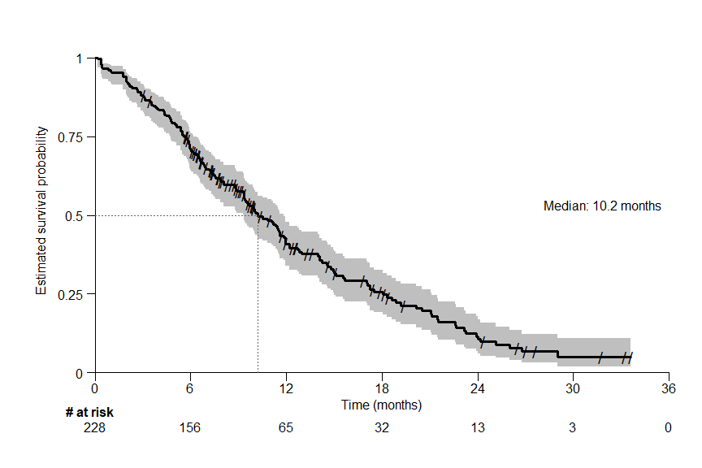

```r
surv.plot(fit.lung.m,
          time.unit = "month",
          segment.quantile = 0.5,
          segment.confint = FALSE
)
```

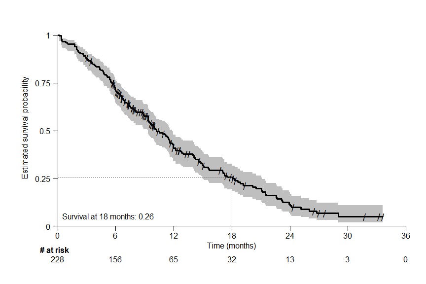

```r
surv.plot(fit.lung.m,
          time.unit = "month",
          segment.timepoint = 18,
          segment.confint = FALSE,
          segment.annotation = "bottomleft"
)
```

Examples for two arms:

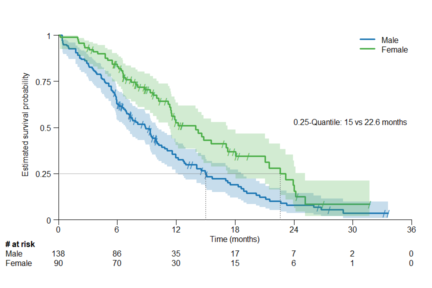

```r
surv.plot(fit.lung.arm.m,
          legend.name = c("Male", "Female"),
          time.unit = "month",
          segment.quantile = 0.25,
          segment.confint = FALSE
)
```

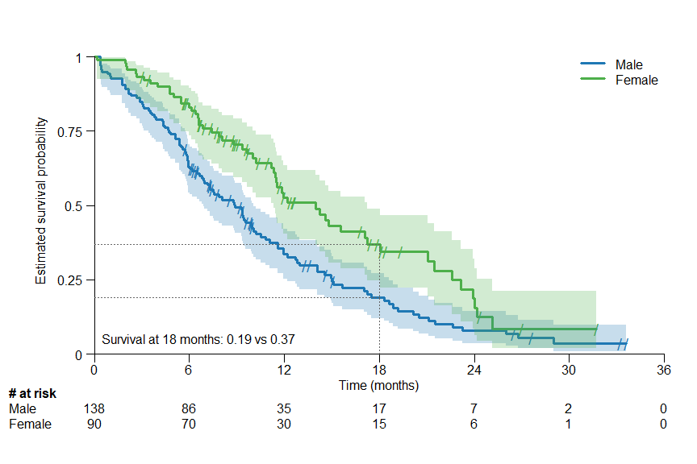

```r
surv.plot(fit.lung.arm.m,
          legend.name = c("Male", "Female"),
          time.unit = "month",
          segment.timepoint = 18,
          segment.confint = FALSE,
          segment.annotation = "bottomleft"
)
```

# Modify confidence interval

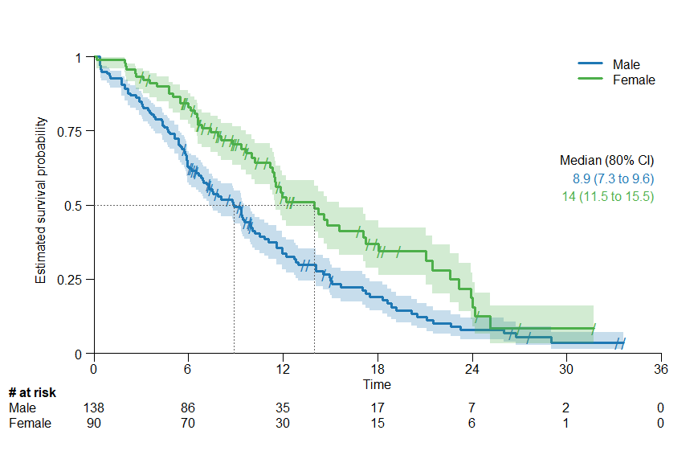

```r
surv.plot(fit.lung.arm.m,
          legend.name = c("Male", "Female"),
          segment.quantile = 0.5,
          conf.int = 0.8
)
```

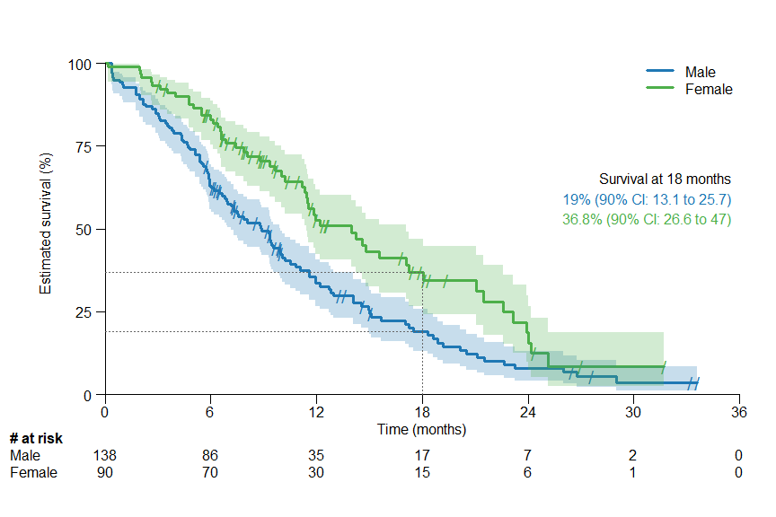

```r
surv.plot(fit.lung.arm.m,
          legend.name = c("Male", "Female"),
          time.unit = "month",
          segment.timepoint = 18,
          y.unit = "percent",
          conf.int = 0.9
)
```

# Include statistics

There are three options for the parameter `stat` to display statistics:

- `logrank`: gives the p value of the log rank test calculated using `survdiff{survival}`.
- `coxph`: gives the hazard ratio (HR) and its 95% CI of the conducted Cox proportional hazards regression using `coxph{survival}`.
- `coxph_logrank`: is a combination of `logrank` and `coxph`.

## `logrank test`

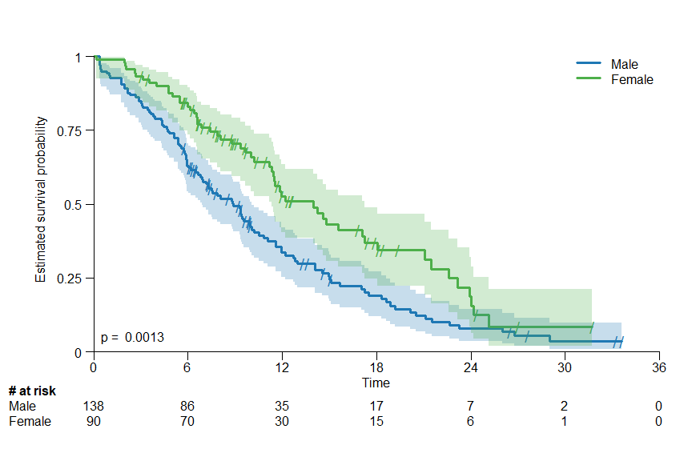

```r
surv.plot(fit.lung.arm.m,
          legend.name = c("Male", "Female"),
          stat = "logrank",
)
```

## `coxph`

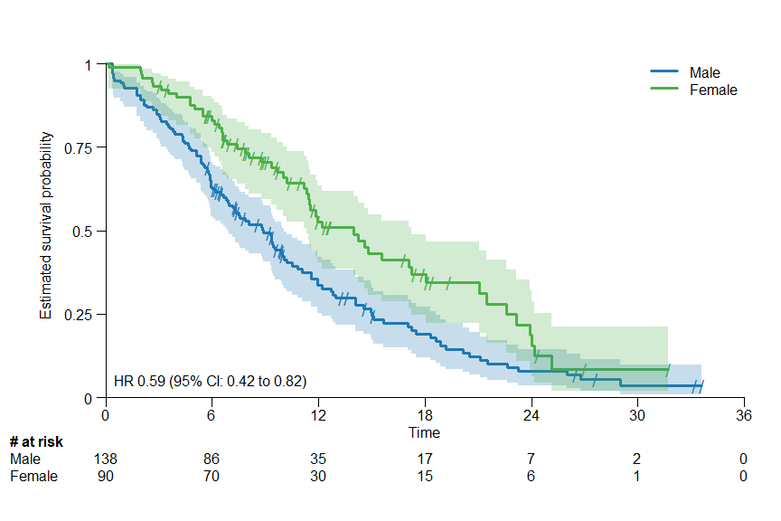

```r
surv.plot(fit.lung.arm.m,
          legend.name = c("Male", "Female"),
          stat = "coxph"
)
```

## `coxph_logrank`

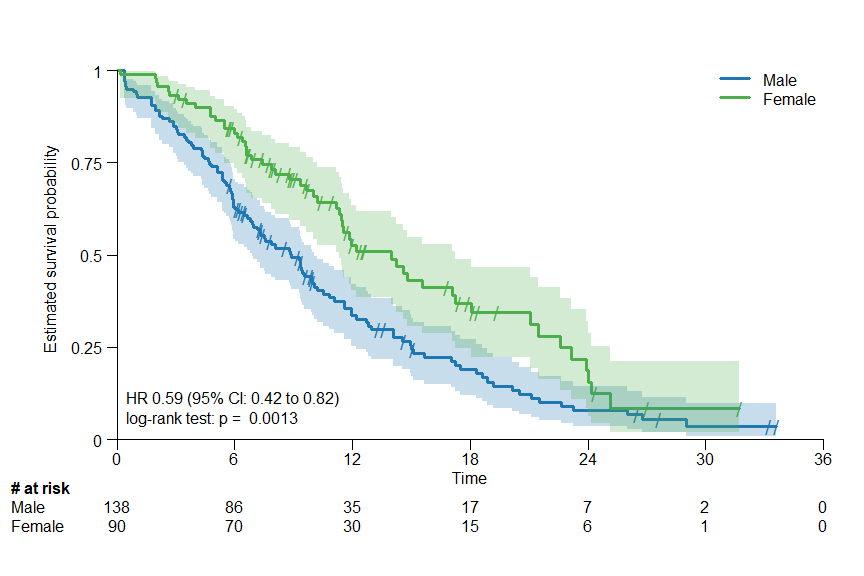

```r
surv.plot(fit.lung.arm.m,
          legend.name = c("Male", "Female"),
          stat = "coxph_logrank"
)
```

# Customisation of the statistics

## Stat position, colour, text size, and text font

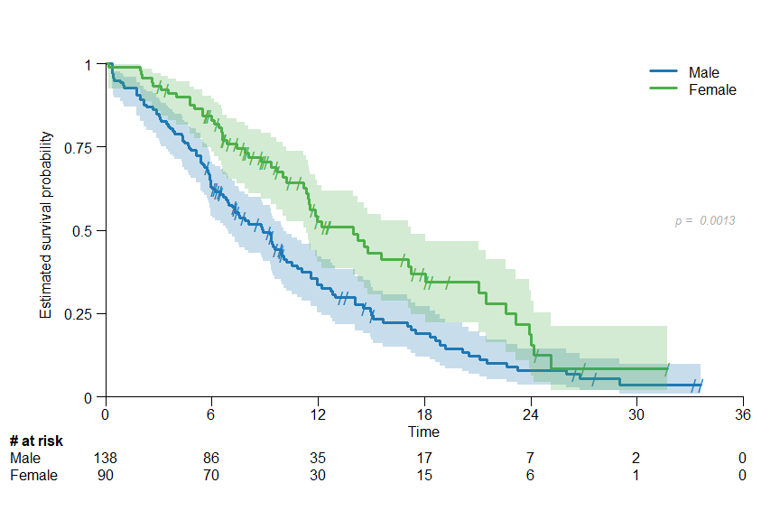

```r
surv.plot(fit.lung.arm.m,
          legend.name = c("Male", "Female"),
          stat = "logrank",
          stat.position = "right",
          stat.col = "darkgrey",
          stat.cex = 0.8,
          stat.font = 3
)
```

## Stat with redfined reference arm and confidence level

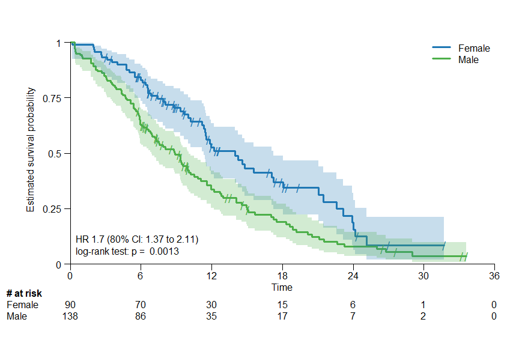

```r
surv.plot(fit.lung.arm.m,
          legend.name = c("Female","Male"),
          stat = "coxph_logrank",
          reference.arm = 2,
          stat.conf.int = 0.80
)
```

## Stat with stratification

In the next example the ECOG performance status is used as stratification factor for the calculation of the statistics.

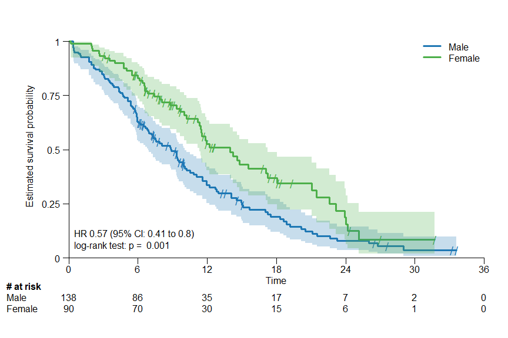

```r
# Fit survival object with stratification

fit_lung_stratified <- survfit(Surv(time.m, status) ~ sex + strata(ph.ecog), data = lung)

surv.plot(fit.lung.arm.m,
          stat.fit = fit_lung_stratified,
          legend.name = c("Male", "Female"),
          stat = "coxph_logrank"
)
```

# Predefined theme options

The following themes are implemented: `SAKK`, `Lancet`, `JCO`, `WCLC`, `ESMO`

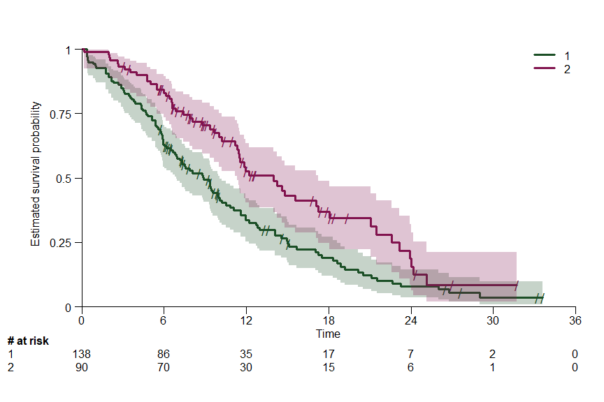

```r
surv.plot(fit.lung.arm.m,
          theme = "ESMO")
```

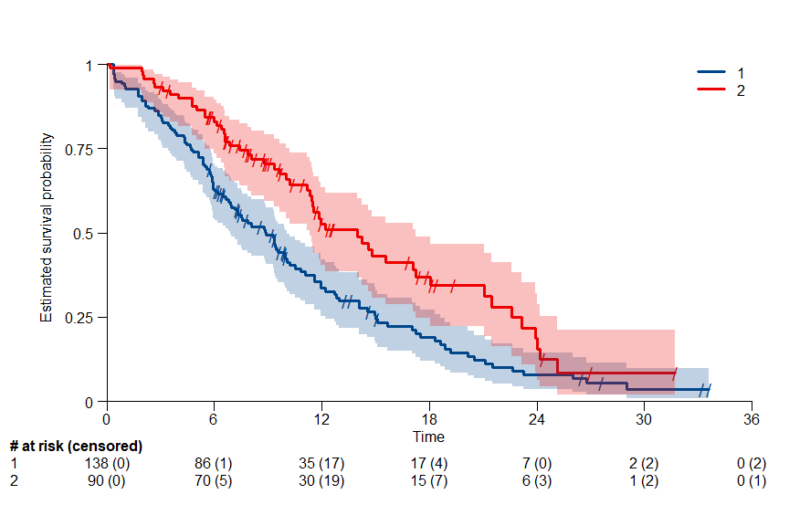

```r
surv.plot(fit.lung.arm.m,
          theme = "Lancet")
```

# Multiple plots using `split.screen()`

```r
split.screen(c(2,2))
```

```
#> [1] 1 2 3 4
```

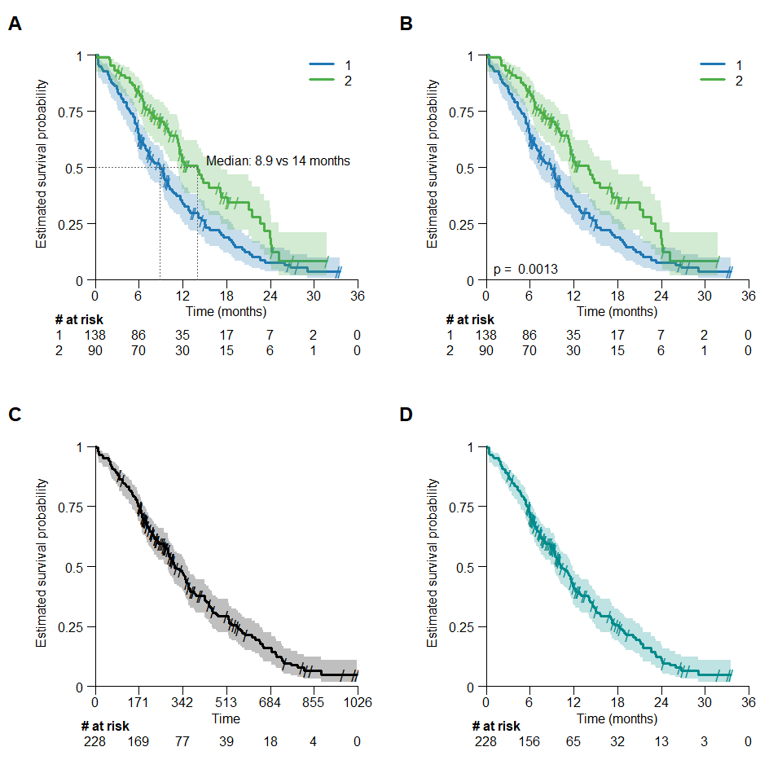

```r
screen(1)
surv.plot(fit.lung.arm.m,
          time.unit = "month",
          segment.quantile = 0.5,
          segment.confint = FALSE,
          letter = "A")
screen(2)
surv.plot(fit.lung.arm.m,
          time.unit = "month",
          segment.confint = FALSE,
          stat = "logrank",
          letter = "B")
screen(3)
surv.plot(fit.lung.d,
          letter = "C")
screen(4)
surv.plot(fit.lung.m,
          time.unit = "month",
          col = "darkcyan",
          letter = "D")
close.screen(all = TRUE)
```

# Export plots as png file

## Figure output for a report

The following examples show how a figure can be exported as png file for a report.

```r
png(file = file.path("kaplan_meier_plot.png"),
    width = 20,
    height = 14,
    units = "cm",
    res = 300)
surv.plot(fit.lung.arm.m,
          risktable.name.position=-4,
          risktable.title.position=-4)
dev.off()
```

## Figure output for a poster

If a bigger font size is needed then this can be done efficiently by choosing a different size of the output file.

```r
png(file = file.path("kaplan_meier_plot_big_font.png"),
    width = 20*0.7,
    height = 14*0.7,
    units = "cm",
    res = 300)
surv.plot(fit.lung.arm.m,
          ylab = "Estimated survival \n (probability)",
          risktable.name.position=-6.5,
          risktable.title.position=-6.5)
dev.off()
```